# Assignment_5_Quant

Alex Cox

10/4/2020

```r
military_data <- read_csv("militarycommute.csv")
```

## Overview

For this assignment, I will first recreate my linear regression predicting average travel time to work (JWMNP) based on the mode of commute (JWTR_label), military service status (MIL_Label), income (PINCP), and age (AGEP) based on 2018 ACS responses in the state of Virginia.

```r
options(scipen=999)
model1 <- lm(JWMNP ~ JWTR_label + MIL_label + PINCP + AGEP,
            data = military_data)

summary(model1)
```

```
##
## Call:
## lm(formula = JWMNP ~ JWTR_label + MIL_label + PINCP + AGEP, data = military_data)
##
## Residuals:
##     Min      1Q  Median      3Q     Max
## -72.451 -15.543  -3.789   9.220 137.998
##
## Coefficients:
##                                                                           Estimate
## (Intercept)                                                           21.753504686
## JWTR_labelBus or trolley bus                                          21.518056839
## JWTR_labelCar, truck, or van                                           3.879034055
## JWTR_labelFerryboat                                                   51.905798804
## JWTR_labelMotorcycle                                                   7.955041622
## JWTR_labelOther method                                                23.114197349
## JWTR_labelRailroad                                                    50.947955471
## JWTR_labelStreetcar or trolley car (carro publico in Puerto Rico)     74.512795664
## JWTR_labelSubway or elevated                                          23.751798261
## JWTR_labelTaxicab                                                     -0.678484163
## JWTR_labelWalked                                                     -16.106896898
## MIL_labelOn active duty in the past, but not now                       4.945162834
## MIL_labelOnly on active duty for training in Reserves/National Guard   5.433439429
## PINCP                                                                  0.000034403
## AGEP                                                                  -0.024427145
##                                                                         Std. Error
## (Intercept)                                                            6.286973010
## JWTR_labelBus or trolley bus                                           6.627060858
## JWTR_labelCar, truck, or van                                           6.212208512
## JWTR_labelFerryboat                                                   14.768504029
## JWTR_labelMotorcycle                                                   8.268321830
## JWTR_labelOther method                                                 6.974136357
## JWTR_labelRailroad                                                     7.189257433
## JWTR_labelStreetcar or trolley car (carro publico in Puerto Rico)     17.538972108
## JWTR_labelSubway or elevated                                           6.608690825
## JWTR_labelTaxicab                                                      9.913573326
## JWTR_labelWalked                                                       6.422345096
## MIL_labelOn active duty in the past, but not now                       0.957248044
## MIL_labelOnly on active duty for training in Reserves/National Guard   1.424190976
## PINCP                                                                  0.000004039
```

[output cut: 40 more lines]

```
## JWTR_labelRailroad                                                   ***
## JWTR_labelStreetcar or trolley car (carro publico in Puerto Rico)    ***
## JWTR_labelSubway or elevated                                         ***
## JWTR_labelTaxicab
## JWTR_labelWalked                                                     *
## MIL_labelOn active duty in the past, but not now                     ***
## MIL_labelOnly on active duty for training in Reserves/National Guard ***
## PINCP                                                                ***
## AGEP
## ---
## Signif. codes:  0 '***' 0.001 '**' 0.01 '*' 0.05 '.' 0.1 ' ' 1
##
## Residual standard error: 23.2 on 5030 degrees of freedom
## Multiple R-squared:  0.1277, Adjusted R-squared:  0.1252
## F-statistic: 52.58 on 14 and 5030 DF,  p-value: < 0.00000000000000022
```

## Log Transforming Income

I first tried log transforming income to see if it would greatly impact my multiple R-squared value from the regression analysis above. It only increased the multiple R-squared value from 0.1277 to 0.1403, but it did slightly change the statistical significance of some of the other variables in comparison. However, I decided it would be useful to keep this log transform for my other analyses.

```r
model2 <- lm(JWMNP ~ JWTR_label + MIL_label + log(PINCP) + AGEP,
            data = military_data)
summary(model2)
```

```
##
## Call:
## lm(formula = JWMNP ~ JWTR_label + MIL_label + log(PINCP) + AGEP,
##     data = military_data)
##
## Residuals:
##     Min      1Q  Median      3Q     Max
## -68.464 -14.809  -4.273   9.066 138.706
##
## Coefficients:
##                                                                       Estimate
## (Intercept)                                                          -24.91215
## JWTR_labelBus or trolley bus                                          18.61483
## JWTR_labelCar, truck, or van                                           1.25941
## JWTR_labelFerryboat                                                   51.08737
## JWTR_labelMotorcycle                                                   4.93002
## JWTR_labelOther method                                                21.32309
## JWTR_labelRailroad                                                    47.09706
## JWTR_labelStreetcar or trolley car (carro publico in Puerto Rico)     70.03213
## JWTR_labelSubway or elevated                                          20.06124
## JWTR_labelTaxicab                                                     -2.08047
## JWTR_labelWalked                                                     -16.09492
## MIL_labelOn active duty in the past, but not now                       4.95997
## MIL_labelOnly on active duty for training in Reserves/National Guard   6.04357
## log(PINCP)                                                             4.84018
## AGEP                                                                  -0.05326
##                                                                      Std. Error
## (Intercept)                                                             7.31653
## JWTR_labelBus or trolley bus                                            6.58666
## JWTR_labelCar, truck, or van                                            6.17298
## JWTR_labelFerryboat                                                    14.66257
## JWTR_labelMotorcycle                                                    8.21418
## JWTR_labelOther method                                                  6.92719
## JWTR_labelRailroad                                                      7.15054
## JWTR_labelStreetcar or trolley car (carro publico in Puerto Rico)      17.41936
## JWTR_labelSubway or elevated                                            6.57351
## JWTR_labelTaxicab                                                       9.84241
## JWTR_labelWalked                                                        6.37631
## MIL_labelOn active duty in the past, but not now                        0.95043
## MIL_labelOnly on active duty for training in Reserves/National Guard    1.41557
```

[output cut: 42 more lines]

```
## JWTR_labelStreetcar or trolley car (carro publico in Puerto Rico)    ***
## JWTR_labelSubway or elevated                                         **
## JWTR_labelTaxicab
## JWTR_labelWalked                                                     *
## MIL_labelOn active duty in the past, but not now                     ***
## MIL_labelOnly on active duty for training in Reserves/National Guard ***
## log(PINCP)                                                           ***
## AGEP                                                                 *
## ---
## Signif. codes:  0 '***' 0.001 '**' 0.01 '*' 0.05 '.' 0.1 ' ' 1
##
## Residual standard error: 23.03 on 5027 degrees of freedom
##   (3 observations deleted due to missingness)
## Multiple R-squared:  0.1403, Adjusted R-squared:  0.1379
## F-statistic:  58.6 on 14 and 5027 DF,  p-value: < 0.00000000000000022
```

## Mutating Data to Aggregate Commuting Modes

In order to analyze broader trends across different types of commuting methods, I decided to mutate my JWTR (mode of transportation to work) in order to aggregate them into broader categories of “Active Modes,” “Motor Vehicles,” “Public Transit,” and “Other.” I noticed similar results among these groups while examining my data in previous weeks, so I thought it would be useful to examine them as 4 broader categories rather than 11 distinct variables.

```r
military_data <- military_data %>%
  mutate(JWTR_groups = case_when(
    JWTR_label=="Walked" ~ "Active_Mode",
    JWTR_label=="Car, truck, or van" ~ "Motor_Vehicle",
    JWTR_label=="Bus or trolley bus" ~ "Public_Transit",
    JWTR_label=="Streetcar or trolley car (carro publico in Puerto Rico)" ~ "Public_Transit",
    JWTR_label=="Bicycle" ~ "Active_Mode",
    JWTR_label=="Subway or elevated" ~ "Public_Transit",
    JWTR_label=="Railroad" ~ "Public_Transit",
    JWTR_label=="Ferryboat" ~ "Public_Transit",
    JWTR_label=="Taxicab" ~ "Motor_Vehicle",
    JWTR_label=="Motorcycle" ~ "Motor_Vehicle",
    JWTR_label=="Other method" ~ "Other"))

model3 <- lm(JWMNP ~ JWTR_groups + MIL_label + log(PINCP) + AGEP,
            data = military_data)
summary(model3)
```

```
##
## Call:
## lm(formula = JWMNP ~ JWTR_groups + MIL_label + log(PINCP) + AGEP,
##     data = military_data)
##
## Residuals:
##     Min      1Q  Median      3Q     Max
## -52.180 -14.847  -4.326   8.996 137.576
##
## Coefficients:
##                                                                       Estimate
## (Intercept)                                                          -40.70421
## JWTR_groupsMotor_Vehicle                                              16.17194
## JWTR_groupsOther                                                      36.24385
## JWTR_groupsPublic_Transit                                             39.59751
## MIL_labelOn active duty in the past, but not now                       5.18708
## MIL_labelOnly on active duty for training in Reserves/National Guard   6.31256
## log(PINCP)                                                             4.91316
## AGEP                                                                  -0.05560
##                                                                      Std. Error
## (Intercept)                                                             4.18655
## JWTR_groupsMotor_Vehicle                                                1.69227
## JWTR_groupsOther                                                        3.58472
## JWTR_groupsPublic_Transit                                               2.24357
## MIL_labelOn active duty in the past, but not now                        0.95521
## MIL_labelOnly on active duty for training in Reserves/National Guard    1.42268
## log(PINCP)                                                              0.40084
## AGEP                                                                    0.02691
##                                                                      t value
## (Intercept)                                                           -9.723
## JWTR_groupsMotor_Vehicle                                               9.556
## JWTR_groupsOther                                                      10.111
## JWTR_groupsPublic_Transit                                             17.649
## MIL_labelOn active duty in the past, but not now                       5.430
## MIL_labelOnly on active duty for training in Reserves/National Guard   4.437
## log(PINCP)                                                            12.257
## AGEP                                                                  -2.067
##                                                                                  Pr(>|t|)
## (Intercept)                                                          < 0.0000000000000002
## JWTR_groupsMotor_Vehicle                                             < 0.0000000000000002
## JWTR_groupsOther                                                     < 0.0000000000000002
## JWTR_groupsPublic_Transit                                            < 0.0000000000000002
## MIL_labelOn active duty in the past, but not now                             0.0000000589
## MIL_labelOnly on active duty for training in Reserves/National Guard         0.0000093128
## log(PINCP)                                                           < 0.0000000000000002
## AGEP                                                                               0.0388
##
## (Intercept)                                                          ***
## JWTR_groupsMotor_Vehicle                                             ***
## JWTR_groupsOther                                                     ***
## JWTR_groupsPublic_Transit                                            ***
## MIL_labelOn active duty in the past, but not now                     ***
## MIL_labelOnly on active duty for training in Reserves/National Guard ***
## log(PINCP)                                                           ***
## AGEP                                                                 *
## ---
## Signif. codes:  0 '***' 0.001 '**' 0.01 '*' 0.05 '.' 0.1 ' ' 1
##
## Residual standard error: 23.17 on 5034 degrees of freedom
##   (3 observations deleted due to missingness)
## Multiple R-squared:  0.1286, Adjusted R-squared:  0.1274
## F-statistic: 106.1 on 7 and 5034 DF,  p-value: < 0.00000000000000022
```

## Adding an Interaction Term

Given that military service status seems to be the most unique variable that I’m examining in my analysis, I wanted to play around with “MIL_label” as my interaction term. Thus, I coded a regression to examine whether or not income and mode of transportation to work make a bigger difference for active duty military members than for reservists and retirees.

Overall, these results seem a little scattered. Overall, active duty military members seem to have shorter commutes than those in other groups. The multiple r-squared value for this model is 0.1359, let’s see how that compares to the numbers for the previous 3 models.

```r
model4 <- lm(JWMNP ~ JWTR_groups + MIL_label + log(PINCP) +
               AGEP + JWTR_groups:MIL_label + log(PINCP):MIL_label,
            data = military_data)
summary(model4)
```

```
##
## Call:
## lm(formula = JWMNP ~ JWTR_groups + MIL_label + log(PINCP) + AGEP +
##     JWTR_groups:MIL_label + log(PINCP):MIL_label, data = military_data)
##
## Residuals:
##     Min      1Q  Median      3Q     Max
## -54.551 -14.847  -4.306   9.018 138.842
##
## Coefficients:
##                                                                                                 Estimate
## (Intercept)                                                                                    -55.01859
## JWTR_groupsMotor_Vehicle                                                                        14.75490
## JWTR_groupsOther                                                                                21.07519
## JWTR_groupsPublic_Transit                                                                       26.92114
## MIL_labelOn active duty in the past, but not now                                                17.84180
## MIL_labelOnly on active duty for training in Reserves/National Guard                            54.85072
## log(PINCP)                                                                                       6.42419
## AGEP                                                                                            -0.05506
## JWTR_groupsMotor_Vehicle:MIL_labelOn active duty in the past, but not now                        2.51239
## JWTR_groupsOther:MIL_labelOn active duty in the past, but not now                               18.71744
## JWTR_groupsPublic_Transit:MIL_labelOn active duty in the past, but not now                      16.17112
## JWTR_groupsMotor_Vehicle:MIL_labelOnly on active duty for training in Reserves/National Guard    1.88843
## JWTR_groupsOther:MIL_labelOnly on active duty for training in Reserves/National Guard          109.82340
## JWTR_groupsPublic_Transit:MIL_labelOnly on active duty for training in Reserves/National Guard  21.36471
## MIL_labelOn active duty in the past, but not now:log(PINCP)                                     -1.47453
## MIL_labelOnly on active duty for training in Reserves/National Guard:log(PINCP)                 -4.74070
##                                                                                                Std. Error
## (Intercept)                                                                                       9.66791
## JWTR_groupsMotor_Vehicle                                                                          2.32945
## JWTR_groupsOther                                                                                  6.71573
## JWTR_groupsPublic_Transit                                                                         4.06873
## MIL_labelOn active duty in the past, but not now                                                 11.18971
## MIL_labelOnly on active duty for training in Reserves/National Guard                             17.74923
## log(PINCP)                                                                                        0.97413
## AGEP                                                                                              0.02704
## JWTR_groupsMotor_Vehicle:MIL_labelOn active duty in the past, but not now                         3.67373
## JWTR_groupsOther:MIL_labelOn active duty in the past, but not now                                 8.16772
## JWTR_groupsPublic_Transit:MIL_labelOn active duty in the past, but not now                        5.24572
## JWTR_groupsMotor_Vehicle:MIL_labelOnly on active duty for training in Reserves/National Guard     8.16245
```

[output cut: 47 more lines]

```
## JWTR_groupsMotor_Vehicle:MIL_labelOn active duty in the past, but not now
## JWTR_groupsOther:MIL_labelOn active duty in the past, but not now                              *
## JWTR_groupsPublic_Transit:MIL_labelOn active duty in the past, but not now                     **
## JWTR_groupsMotor_Vehicle:MIL_labelOnly on active duty for training in Reserves/National Guard
## JWTR_groupsOther:MIL_labelOnly on active duty for training in Reserves/National Guard          ***
## JWTR_groupsPublic_Transit:MIL_labelOnly on active duty for training in Reserves/National Guard *
## MIL_labelOn active duty in the past, but not now:log(PINCP)
## MIL_labelOnly on active duty for training in Reserves/National Guard:log(PINCP)                **
## ---
## Signif. codes:  0 '***' 0.001 '**' 0.01 '*' 0.05 '.' 0.1 ' ' 1
##
## Residual standard error: 23.1 on 5026 degrees of freedom
##   (3 observations deleted due to missingness)
## Multiple R-squared:  0.1359, Adjusted R-squared:  0.1333
## F-statistic:  52.7 on 15 and 5026 DF,  p-value: < 0.00000000000000022
```

## Which Model Version is Best?

When I graph the adjusted R-squared values for the 4 models above, it appears that Model 2 (in which I log-transformed income) is the clear winner with an adjusted R-squared value of 0.1379.

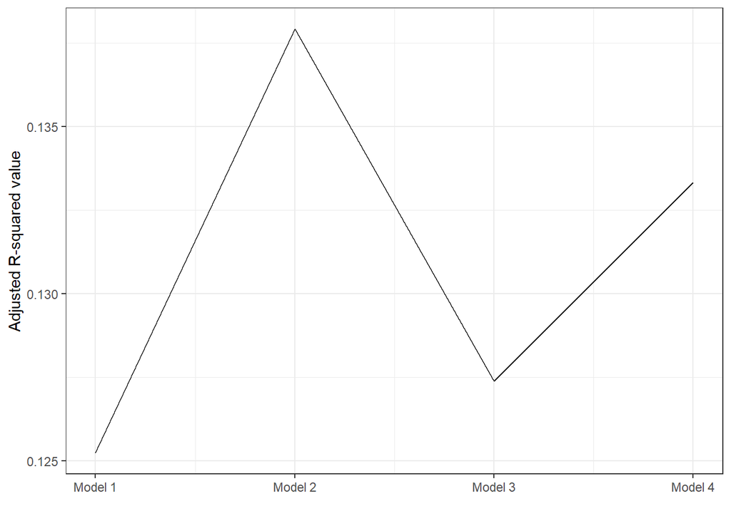

```r
ModelFit <- tibble(model = c(1, 2, 3, 4),
                   R_square = c(summary(model1)$adj.r.squared,
                                summary(model2)$adj.r.squared,
                                summary(model3)$adj.r.squared,
                                summary(model4)$adj.r.squared))

ggplot(ModelFit, aes(x = model, y = R_square)) +
  geom_line() +
  scale_x_continuous(name = "",
                   breaks = breaks <- seq(1, 4, by = 1),
                   labels = paste("Model", breaks)) +
  scale_y_continuous(name = "Adjusted R-squared value") +
  theme_bw()
```

By modelling the predicted relationship between income and commute time based on military service status, we can see how active duty military members tend to have lower commute times on average.

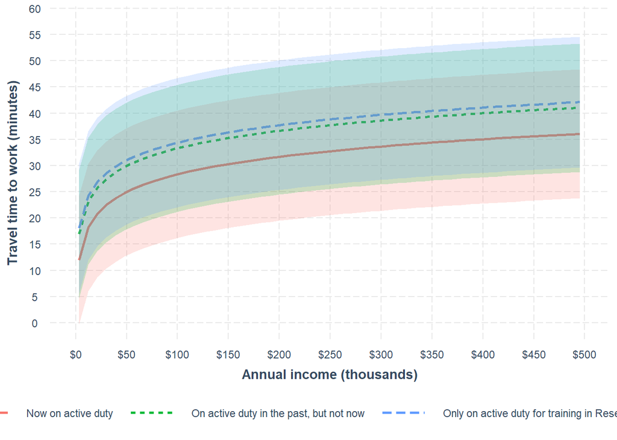

```r
interact_plot(model2, pred = PINCP, modx = MIL_label, interval = TRUE) +
  scale_x_continuous(name = "Annual income (thousands)",
                     limits = c(0, 500000),
                     breaks = breaks <- seq(0, 500000, by = 50000),
                     labels = paste("$",
                                    prettyNum(breaks/1000, big.mark = "'"),
                                    sep = "")) +
  scale_y_continuous(name = "Travel time to work (minutes)",
                     breaks = seq(0, 60, by = 5)) +
  scale_color_discrete(name = "") +
  scale_linetype_discrete(name = "") +
  scale_fill_discrete(name = "") +
  theme(legend.position = "bottom")
```